# Practical Machine Learning Assignment

R.Z.

## Overview

This document is the report for the Peer Assessment project from Coursera’s course Practical Machine Learning. The purpose of this analysis is to determine the manner in which 6 participants performed the Unilateral Dumbbell Bicep Curl using Accelerometers located on the belt, forearm and arm to record the readings. This exercise was performed in 5 different ways;

- Exactly according to the specification (Class A)
- Throwing the elbows to the front (Class B)
- Lifting the dumbbell only halfway (Class C)
- Lowering the dumbbell only halfway (Class D)
- Throwing the hips to the front (Class E)

## Background

The following is an excerpt from the coursera project description;

“Using devices such as Jawbone Up, Nike FuelBand, and Fitbit it is now possible to collect a large amount of data about personal activity relatively inexpensively. These type of devices are part of the quantified self movement – a group of enthusiasts who take measurements about themselves regularly to improve their health, to find patterns in their behavior, or because they are tech geeks. One thing that people regularly do is quantify how much of a particular activity they do, but they rarely quantify how well they do it. In this project, your goal will be to use data from accelerometers on the belt, forearm, arm, and dumbell of 6 participants. They were asked to perform barbell lifts correctly and incorrectly in 5 different ways. More information is available from the website here: http://web.archive.org/web/20161224072740/http:/groupware.les.inf.puc-rio.br/har (see the section on the Weight Lifting Exercise Dataset).”

## Data Loading, Partitioning & Cleaning

Loading required libraries and setting the seed.

```r
#preparing environment
library(caret)
library(ggplot2)
library(randomForest)
library(rpart)
library(rpart.plot)
library(rattle)

#setting seed
set.seed(2020)
```

### Loading the training and testing datasets.

```r
url_train <- 'http://d396qusza40orc.cloudfront.net/predmachlearn/pml-training.csv'
url_quiz  <- 'http://d396qusza40orc.cloudfront.net/predmachlearn/pml-testing.csv'

#removing white spaces, NA and #DIV/0!

df_train <- read.csv(url(url_train), strip.white = TRUE, na.strings = c("NA","", "#DIV/0!"))
df_train <-df_train[,colSums(is.na(df_train)) == 0]

df_quiz  <- read.csv(url(url_quiz),  strip.white = TRUE, na.strings = c("NA","", "#DIV/0!"))
df_quiz <-df_quiz[,colSums(is.na(df_quiz)) == 0]
```

```r
dim(df_train)
```

```
## [1] 19622    60
```

```r
dim(df_quiz)
```

```
## [1] 20 60
```

Removing the non-predictors from the dataset (e.g. index, time, subject name etc.)

```r
#removing non-predictors
df_train  <-df_train[,-c(1:7)]
df_quiz <-df_quiz[,-c(1:7)]
dim(df_train)
```

```
## [1] 19622    53
```

### Data Partioning

Creating two partitions (75% & 25%) in the original training dataset.

```r
set.seed(2020)
trainingSample<- createDataPartition(df_train$classe, p = 0.75, list = FALSE)
training_set<- df_train[trainingSample,]
test_set<- df_train[-trainingSample,]
dim(training_set)
```

```
## [1] 14718    53
```

```r
dim(test_set)
```

```
## [1] 4904   53
```

Checking near-zero variance from dataset.

```r
#checking for near-zero variance
nzv.train<-nzv(df_train[,-ncol(df_train)],saveMetrics=TRUE)
rownames(nzv.train)
```

```
##  [1] "roll_belt"            "pitch_belt"           "yaw_belt"
##  [4] "total_accel_belt"     "gyros_belt_x"         "gyros_belt_y"
##  [7] "gyros_belt_z"         "accel_belt_x"         "accel_belt_y"
## [10] "accel_belt_z"         "magnet_belt_x"        "magnet_belt_y"
## [13] "magnet_belt_z"        "roll_arm"             "pitch_arm"
## [16] "yaw_arm"              "total_accel_arm"      "gyros_arm_x"
## [19] "gyros_arm_y"          "gyros_arm_z"          "accel_arm_x"
## [22] "accel_arm_y"          "accel_arm_z"          "magnet_arm_x"
## [25] "magnet_arm_y"         "magnet_arm_z"         "roll_dumbbell"
## [28] "pitch_dumbbell"       "yaw_dumbbell"         "total_accel_dumbbell"
## [31] "gyros_dumbbell_x"     "gyros_dumbbell_y"     "gyros_dumbbell_z"
## [34] "accel_dumbbell_x"     "accel_dumbbell_y"     "accel_dumbbell_z"
## [37] "magnet_dumbbell_x"    "magnet_dumbbell_y"    "magnet_dumbbell_z"
## [40] "roll_forearm"         "pitch_forearm"        "yaw_forearm"
## [43] "total_accel_forearm"  "gyros_forearm_x"      "gyros_forearm_y"
## [46] "gyros_forearm_z"      "accel_forearm_x"      "accel_forearm_y"
## [49] "accel_forearm_z"      "magnet_forearm_x"     "magnet_forearm_y"
## [52] "magnet_forearm_z"
```

```r
dim(nzv.train)[1]
```

```
## [1] 52
```

## Predictive Models: Model Fitting

### Random Forest Model

```r
#model fitting
#using cross validation
rf_ctrl <- trainControl(method="cv", number=3, verboseIter=FALSE)
modFit_rf <- train(classe ~ ., data=training_set, method="rf",
                          trControl=rf_ctrl)
modFit_rf$finalModel
```

```
##
## Call:
##  randomForest(x = x, y = y, mtry = param$mtry)
##                Type of random forest: classification
##                      Number of trees: 500
## No. of variables tried at each split: 2
##
##         OOB estimate of  error rate: 0.65%
## Confusion matrix:
##      A    B    C    D    E  class.error
## A 4181    2    0    0    2 0.0009557945
## B   16 2824    8    0    0 0.0084269663
## C    0   17 2547    3    0 0.0077911959
## D    0    0   40 2370    2 0.0174129353
## E    0    0    1    5 2700 0.0022172949
```

```r
#prediction using test data set

predict_rf <- predict(modFit_rf, newdata=test_set)
confMatrix_rf <- confusionMatrix(predict_rf, test_set$classe)

confMatrix_rf
```

```
## Confusion Matrix and Statistics
##
##           Reference
## Prediction    A    B    C    D    E
##          A 1393    4    0    0    0
##          B    2  943   11    0    0
##          C    0    2  844   17    0
##          D    0    0    0  787    3
##          E    0    0    0    0  898
##
## Overall Statistics
##
##                Accuracy : 0.992
##                  95% CI : (0.9891, 0.9943)
##     No Information Rate : 0.2845
##     P-Value [Acc > NIR] : < 2.2e-16
##
##                   Kappa : 0.9899
##
##  Mcnemar's Test P-Value : NA
##
## Statistics by Class:
##
##                      Class: A Class: B Class: C Class: D Class: E
## Sensitivity            0.9986   0.9937   0.9871   0.9789   0.9967
## Specificity            0.9989   0.9967   0.9953   0.9993   1.0000
## Pos Pred Value         0.9971   0.9864   0.9780   0.9962   1.0000
## Neg Pred Value         0.9994   0.9985   0.9973   0.9959   0.9993
## Prevalence             0.2845   0.1935   0.1743   0.1639   0.1837
## Detection Rate         0.2841   0.1923   0.1721   0.1605   0.1831
## Detection Prevalence   0.2849   0.1949   0.1760   0.1611   0.1831
## Balanced Accuracy      0.9987   0.9952   0.9912   0.9891   0.9983
```

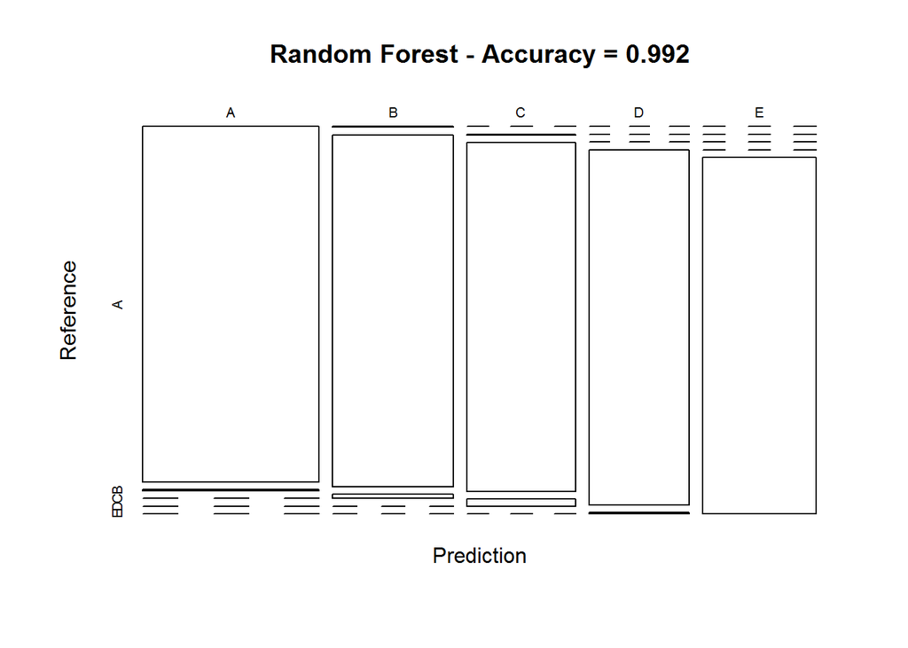

```r
#plotting results

plot(confMatrix_rf$table, col = confMatrix_rf$byClass,
     main = paste("Random Forest - Accuracy =",
                  round(confMatrix_rf$overall['Accuracy'], 4)))
```

### Decision Tree

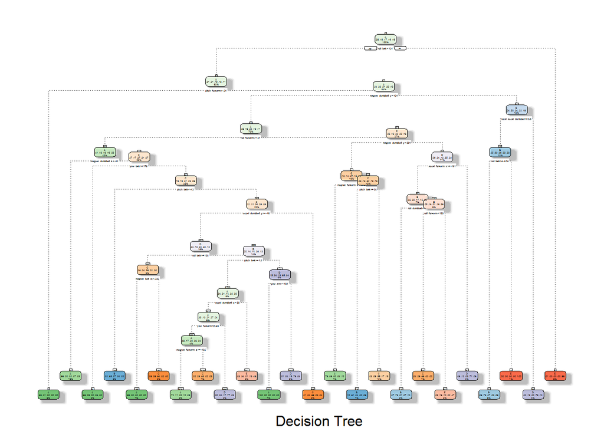

```r
#model fitting
modFit_dt <- rpart(classe ~ ., data=training_set, method="class")

fancyRpartPlot(modFit_dt, sub = "Decision Tree")
```

```r
#prediction using test data set
predict_dt <- predict(modFit_dt, newdata=test_set, type="class")
confMatrix_dt <- confusionMatrix(predict_dt, test_set$classe)
confMatrix_dt
```

```
## Confusion Matrix and Statistics
##
##           Reference
## Prediction    A    B    C    D    E
##          A 1260  175   24   72   31
##          B   40  486   37   24   46
##          C   45  108  724  142   97
##          D   27   69   53  509   46
##          E   23  111   17   57  681
##
## Overall Statistics
##
##                Accuracy : 0.7463
##                  95% CI : (0.7339, 0.7585)
##     No Information Rate : 0.2845
##     P-Value [Acc > NIR] : < 2.2e-16
##
##                   Kappa : 0.678
##
##  Mcnemar's Test P-Value : < 2.2e-16
##
## Statistics by Class:
##
##                      Class: A Class: B Class: C Class: D Class: E
## Sensitivity            0.9032   0.5121   0.8468   0.6331   0.7558
## Specificity            0.9139   0.9628   0.9032   0.9524   0.9480
## Pos Pred Value         0.8067   0.7678   0.6487   0.7230   0.7660
## Neg Pred Value         0.9596   0.8916   0.9654   0.9298   0.9452
## Prevalence             0.2845   0.1935   0.1743   0.1639   0.1837
## Detection Rate         0.2569   0.0991   0.1476   0.1038   0.1389
## Detection Prevalence   0.3185   0.1291   0.2276   0.1436   0.1813
## Balanced Accuracy      0.9086   0.7375   0.8750   0.7928   0.8519
```

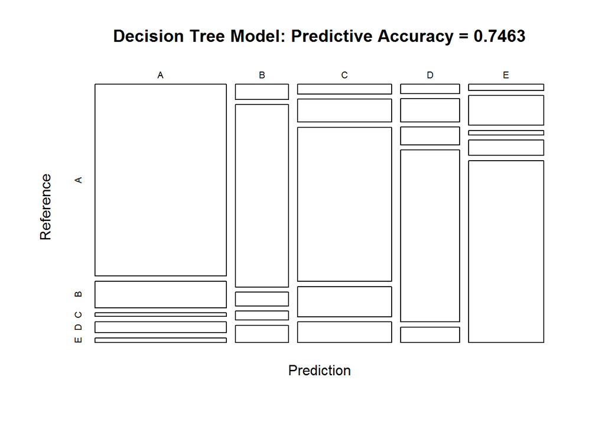

```r
#plot
plot(confMatrix_dt$table, col = confMatrix_dt$byClass,
     main = paste("Decision Tree Model: Predictive Accuracy =",
                  round(confMatrix_dt$overall['Accuracy'], 4)))
```

### Generalised Boosted Model

```r
#model fitting

gbm_ctrl <- trainControl(method = "repeatedcv", number = 3, repeats = 2)
modFit_gbm  <- train(classe ~ ., data = training_set, method = "gbm",
                  trControl = gbm_ctrl, verbose = FALSE)
modFit_gbm$finalModel
```

```
## A gradient boosted model with multinomial loss function.
## 150 iterations were performed.
## There were 52 predictors of which 52 had non-zero influence.
```

```r
#prediction using test data set
predict_gbm <- predict(modFit_gbm, newdata=test_set)
confMatrix_gbm <- confusionMatrix(predict_gbm, test_set$classe)
confMatrix_gbm
```

```
## Confusion Matrix and Statistics
##
##           Reference
## Prediction    A    B    C    D    E
##          A 1366   16    0    0    0
##          B   18  900   21    1   12
##          C    7   29  825   28    7
##          D    2    3    7  771   12
##          E    2    1    2    4  870
##
## Overall Statistics
##
##                Accuracy : 0.9649
##                  95% CI : (0.9594, 0.9699)
##     No Information Rate : 0.2845
##     P-Value [Acc > NIR] : < 2.2e-16
##
##                   Kappa : 0.9557
##
##  Mcnemar's Test P-Value : 7.248e-06
##
## Statistics by Class:
##
##                      Class: A Class: B Class: C Class: D Class: E
## Sensitivity            0.9792   0.9484   0.9649   0.9590   0.9656
## Specificity            0.9954   0.9869   0.9825   0.9941   0.9978
## Pos Pred Value         0.9884   0.9454   0.9208   0.9698   0.9898
## Neg Pred Value         0.9918   0.9876   0.9925   0.9920   0.9923
## Prevalence             0.2845   0.1935   0.1743   0.1639   0.1837
## Detection Rate         0.2785   0.1835   0.1682   0.1572   0.1774
## Detection Prevalence   0.2818   0.1941   0.1827   0.1621   0.1792
## Balanced Accuracy      0.9873   0.9676   0.9737   0.9766   0.9817
```

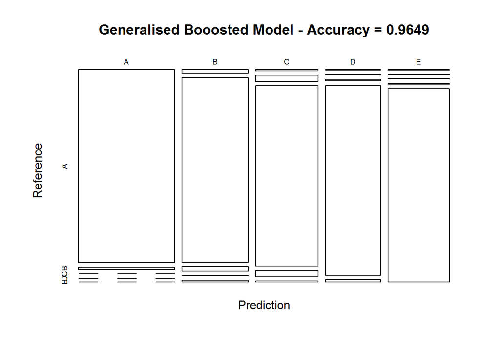

```r
#plot
plot(confMatrix_gbm$table, col = confMatrix_gbm$byClass,
     main = paste("Generalised Booosted Model - Accuracy =", round(confMatrix_gbm$overall['Accuracy'], 4)))
```

## Choosing the Best Prediction Model for Quiz/Testing Dataset

The aforementioned 3 models have the following accuracies;

```r
accuracies <- data.frame(
  Model = c('RF', 'DT', 'GBM'),
  Accuracy = rbind(confMatrix_rf$overall[1], confMatrix_dt$overall[1], confMatrix_gbm$overall[1])
)
print(accuracies)
```

```
##   Model  Accuracy
## 1    RF 0.9920473
## 2    DT 0.7463295
## 3   GBM 0.9649266
```

Based on the accuracies seen above, we can see that the Random Forest Model and gradient boosting model outperform the Decision Tree (CART) model. However, Random Forest Model is slightly more accurate and as such is used to predict the quiz results.

## Conclusion

The Random Forest Model has an accuracy of 99.2 and an Out of Sample Error of 0.80. Using this model in the course project prediction quiz resulted in 20/20 correct answers.

```r
predict_quiz <- predict(modFit_rf, newdata=df_quiz)
predict_quiz
```

```
##  [1] B A B A A E D B A A B C B A E E A B B B
## Levels: A B C D E
```